# AI Aligned by Benchmarking

[figure not shown]

### INTRODUCTION

#### Narrative

This dashboard shows that it is practical to collect live benchmark data and provides visual intuition into the value of this data for model selection. By the end of the story, we conclude that AI alignment through benchmark comparisons is operationalizable and requires a nuanced understanding of the details to be enacted safely. The dashboard then points to a second dashboard that explains some nuances and provides a mockup of a potential community practice.

The live data sources were gathered from the sources acknowledged below. Through their efforts, this dashboard was made viable.

#### Acknowledgements

The live datasets are gathered from the following sources:

1. *[Artificial.AI](https://artificialanalysis.ai/):* Artificial Analysis performs intelligence, quality, performance and price benchmarking on AI models, inference API endpoints and systems. This section of our website describes our benchmarking methodology, including both our quality benchmarking and performance benchmarking.
2. *[/oolong-tea-2026](https://github.com/oolong-tea-2026/arena-ai-leaderboards):* Auto-updated daily snapshots of every Arena AI (formerly LMSYS Chatbot Arena) leaderboard in structured JSON.
3. *[Epoch](https://epoch.ai/):* Investigating the trajectory of AI for the benefit of society.

### *1 a:* Coverage

[interactive chart not shown]

Artificial Analysis (https://artificialanalysis.ai) provides its gathered benchmarks for free through a REST API. Their coverage spans a range of benchmarks (around 10) based on their own AGI benchmark. Artificial Analysis also provides a detailed dashboard that you may consider interacting with in your own research.

> The graph is dynamic. Hovering over a point will display a bar with further information.

### *1 b:* Best models

| Model | Domain | Benchmark | Details |
| --- | --- | --- | --- |
| GPT-5.5 (xhigh) | Agentic | tau_banking | [Link](https://github.com/sierra-research/tau2-bench) t2-Bench: benchmark for Tool-Agent-User interaction in real-world domains. |
| JT-35B-Flash | Agentic | tau2 | [Link](https://github.com/sierra-research/tau2-bench) t2-Bench: benchmark for Tool-Agent-User interaction in real-world domains. |
| GLM-5.2 (max) | Agentic | tau2 | [Link](https://github.com/sierra-research/tau2-bench) t2-Bench: benchmark for Tool-Agent-User interaction in real-world domains. |
| Claude Fable 5 (Adaptive Reasoning, Max Effort, Opus 4.8 Fallback) | Agentic | terminalbench_hard | [Link](https://artificialanalysis.ai/methodology/intelligence-benchmarking#aa-lcr) Terminal-Bench: agentic benchmark evaluating agents on software engineering, sysadmin, and game-playing via a termina… |
| Claude Opus 4.8 (Adaptive Reasoning, Max Effort) | Agentic | terminalbench_v2_1 | [Link](https://artificialanalysis.ai/methodology/intelligence-benchmarking#aa-lcr) Terminal-Bench: agentic benchmark evaluating agents on software engineering, sysadmin, and game-playing via a termina… |
| Claude Fable 5 (Adaptive Reasoning, Max Effort, Opus 4.8 Fallback) | Agentic | terminalbench_v2_1 | [Link](https://artificialanalysis.ai/methodology/intelligence-benchmarking#aa-lcr) Terminal-Bench: agentic benchmark evaluating agents on software engineering, sysadmin, and game-playing via a termina… |
| Claude Fable 5 (Adaptive Reasoning, Max Effort, Opus 4.8 Fallback) | AGI | artificial_analysis_intelligence_index | [Link](https://artificialanalysis.ai/evaluations/artificial-analysis-intelligence-index) Artificial Analysis Intelligence Index combines performance across ten evaluations: GDPval-AA, t2-Bench Telecom… |
| Claude Fable 5 (Adaptive Reasoning, Max Effort, Opus 4.8 Fallback) | AGI | hle | [Link](https://agi.safe.ai) Humanity’s Last Exam: 2,500 challenging questions across over a hundred subjects at the frontier of human knowledge. |
| Claude Fable 5 (Adaptive Reasoning, Max Effort, Opus 4.8 Fallback) | Coding | artificial_analysis_coding_index | [Link](https://artificialanalysis.ai/evaluations/artificial-analysis-intelligence-index) Artificial Analysis Intelligence Index combines performance across ten evaluations: GDPval-AA, t2-Bench Telecom… |
| Gemini 3 Pro Preview (high) | Coding | livecodebench | [Link](https://livecodebench.github.io) LiveCodeBench: holistic, contamination-free evaluation of LLMs for code, updated continuously with new problems. |
| Claude Fable 5 (Adaptive Reasoning, Max Effort, Opus 4.8 Fallback) | Coding | scicode | [Link](https://scicode-bench.github.io) SciCode: models a realistic scientist workflow of identifying science concepts and transforming them into simulation code. |
| Grok 4.3 (medium) | Instructions | ifbench | [Link](https://arxiv.org/abs/2507.02833) IFBench |
| GPT-5.2 Codex (xhigh) | Long context Reasoning | lcr | [Link](https://artificialanalysis.ai/methodology/intelligence-benchmarking#aa-lcr) AA-LCR: measures ability to extract and synthesise information from long-form documents ranging from 10k to 100k toke… |
| GPT-5 (high) | Maths | aime | [Link](https://artificialanalysis.ai/evaluations/aime-2025) AIME 2025: all 30 problems from the 2025 American Invitational Mathematics Examination. |
| GPT-5.2 (xhigh) | Maths | aime_25 | [Link](https://artificialanalysis.ai/evaluations) AIM25 |
| GPT-5.2 (xhigh) | Maths | artificial_analysis_math_index | [Link](https://artificialanalysis.ai/evaluations/artificial-analysis-intelligence-index) Artificial Analysis Intelligence Index combines performance across ten evaluations: GDPval-AA, t2-Bench Telecom… |
| Gemini 3.1 Pro Preview | Reasoning | gpqa | [Link](https://github.com/idavidrein/gpqa) GPQA: 448 multiple-choice questions written by domain experts in biology, physics, and chemistry. |
| Gemini 3 Pro Preview (high) | Reasoning | mmlu_pro | [Link](https://github.com/TIGER-AI-Lab/MMLU-Pro) MMLU-Pro: a more challenging and robust benchmark for language models across 12K complex questions in various disciplines. |
| GPT-5 (high) | Saturated | math_500 | [Link](https://artificialanalysis.ai/evaluations/math-500) MATH-500: 500 problems spanning algebra, geometry, number theory, and probability, requiring step-by-step solutions. |

> This table shows the best performing models across all benchmarks.

### *1 c:* Finding the balance

[interactive chart not shown]

> You can see that some models perform well on the benchmark at considerably less cost than the best performing model.

### *1 d:* Exploring

[interactive chart not shown]

Lots of actionable information on one graph.

> Click on a point to reveal the model name and benchmark. The click also fixs all the datpoints for a given benchmark in focus. Click again to reset the view.

### *2 a:* Human Judgement

| Arena | models_benchmarked | best_model | ranked_second_model |
| --- | --- | --- | --- |
| agent | 28 | Claude Fable 5 (High) | Claude Opus 4.8 (Thinking) |
| code | 16 | claude-fable-5 | glm-5.2 (max) |
| document | 29 | claude-opus-4-6 | claude-opus-4-6-thinking |
| image-edit | 49 | gpt-image-2 (medium) | mai-image-2.5 |
| image-to-video | 41 | gemini-omni-flash | dreamina-seedance-2.0-720p |
| search | 31 | claude-opus-4-6-search | gpt-5.5-search |
| text-to-image | 70 | gpt-image-2 (medium) | reve-2.0 |
| text-to-video | 41 | gemini-omni-flash | dreamina-seedance-2.0-720p |
| text | 20 | claude-fable-5 | claude-opus-4-6-thinking |
| video-edit | 6 | dreamina-seedance-2.0-720p | happyhorse-1.0 |
| vision | 20 | claude-opus-4-7-thinking | claude-fable-5 |

> Arena’s allow humans to choose (online) between different models on a given task. The table shows the results of a human judgement benchmarks.

### *2 b:* Ranking

[interactive chart not shown]

> Opensource models are ranked on a leaderboard based on human judgements. Some of the Open Source models are near the top of the leaderboard and might be useful once we take into account the need for Digital Sovereignty or keeping your data within your own data center.

### *2 b:* Ranking Safety

[interactive chart not shown]

*CISCO LLM Security Leadership board*

Comprehensive model safety and security rankings, including single-turn score, multi-turn score, and detailed metrics.

[See](https://leaderboard.aidefense.cisco.com/rankings)

Other available Security benchmarks:

- [CVE=Benchmark](https://github.com/uiuc-kang-lab/cve-bench) Evaluating AI agents on real world web vulnerabilities and exploits collected from National Vulnerability Database. CVE-Bench includes 40 critical-severity Common Vulnerability and Exposures (CVE) with the reference automatic exploits available on requests.
- [TOSSS](https://github.com/MarcT0K/TOSSS-LLM-Benchmark) A benchmark that measures the ability of LLMs to choose between secure and vulnerable code snippets.

### *2 c:* Updating and Routing

| id | open_weight | added_at | url |
| --- | --- | --- | --- |
| north-mini-code-1.0 | TRUE | 2026-06-20 15:53:02 | [Cohere](https://llm-stats.com/models/north-mini-code-1.0) |
| command-a-plus-05-2026 | TRUE | 2026-06-20 15:53:01 | [Cohere](https://llm-stats.com/models/command-a-plus-05-2026) |
| qwen3.7-plus | FALSE | 2026-06-16 23:57:45 | [Alibaba Cloud / Qwen Team](https://llm-stats.com/models/qwen3.7-plus) |
| nemotron-3-ultra-550b-a55b | TRUE | 2026-06-16 23:57:38 | [NVIDIA](https://llm-stats.com/models/nemotron-3-ultra-550b-a55b) |
| glm-5.2 | TRUE | 2026-06-16 19:03:52 | [Zhipu AI](https://llm-stats.com/models/glm-5.2) |
| kimi-k2.7-code | TRUE | 2026-06-12 23:25:40 | [Moonshot AI](https://llm-stats.com/models/kimi-k2.7-code) |
| mimo-v2.5-pro | TRUE | 2026-06-10 21:36:16 | [Xiaomi](https://llm-stats.com/models/mimo-v2.5-pro) |
| mimo-v2.5 | TRUE | 2026-06-10 21:36:16 | [Xiaomi](https://llm-stats.com/models/mimo-v2.5) |
| diffusiongemma-26b-a4b-it | TRUE | 2026-06-10 21:12:04 | [Google](https://llm-stats.com/models/diffusiongemma-26b-a4b-it) |
| claude-fable-5 | FALSE | 2026-06-09 20:20:02 | [Anthropic](https://llm-stats.com/models/claude-fable-5) |

[LLM-Stats](https://llm-stats.com/) provides a live feed of model updates, including newly added models to the ecosystem. We can use this type of information to keep our benchmarks up to date and to identify promising new models for testing.

LLM-Stats also provides a routing service that automatically directs API calls to the best-performing model. We can use such a service to ensure that we always use the near best available model for specific capabilities. For a more complex community scorecard, it would require a discussion with a provider of routing services.

### *3 b:* LLM input / Output

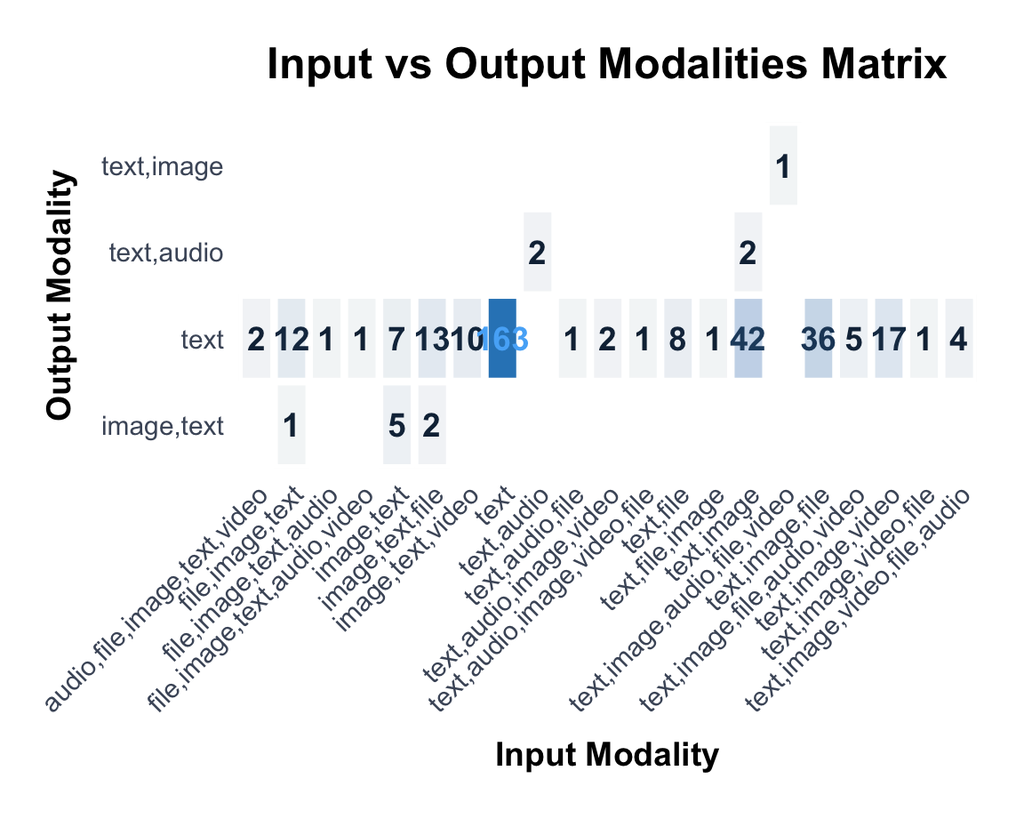

[OpenRouter](https://openrouter.ai/data) operates one of the largest AI inference platforms in the world, generating an authoritative empirical dataset relied upon by government agencies, academic researchers, major industry analysts, and global media outlets.

Here we use their dataset on the input and output modality of the models that they measure. For policymakers, by doing so, we can keep track of the expanding range of modalities and their popularity. This is an important consideration as you select benchmarks relevant to the LLMs in your organisation.

### Conclusions

Choose AI models based on our values is possible via a set of current benchmarks. Much of the necessary benchmarks are available, but …

*It is Nuanced:*

- Not all benchmarks are created equal.
- Different domains have different capability needs.
- Some benchmarks are more accessible than others.
- We might run our own benchmarks for missing models.
- It is only an estimate, but the higher (and more popular) the benchmarks, the more reliable the estimate.
- There are many model variations (Size, fine-tuning, etc.), and the benchmarks capture only a subset of them.
- Fine-tuning can improve models for our specific tasks, so we will have more models to test in the future.
- Benchmarks become less reliable over time due to Saturation effects such as models trained on benchmark data.

> AI alignment requires a nuanced understanding of the details for us to enact safely. However, the payoff is great.

We do need a community process. Here is a [mockup of the dashboard](https://cedanl.github.io/AI-Alignment/Dashboard/info_benchmarks.html#visualization) that supports such a process.